# Codebook Study 2

### Metadata

#### Description

**Dataset name**: The Effects of Making Public Service Employees Aware of Their Prosocial and Societal Impact: A Micro-Intervention

Dataset for Study 2 of Vogel, D., & Willems, J. The Effects of Making Public Service Employees Aware of Their Prosocial and Societal Impact: A Micro-Intervention. Journal of Public Administration Research and Theory.

**Metadata for search engines**

## Variables

### id

ID

#### Distribution

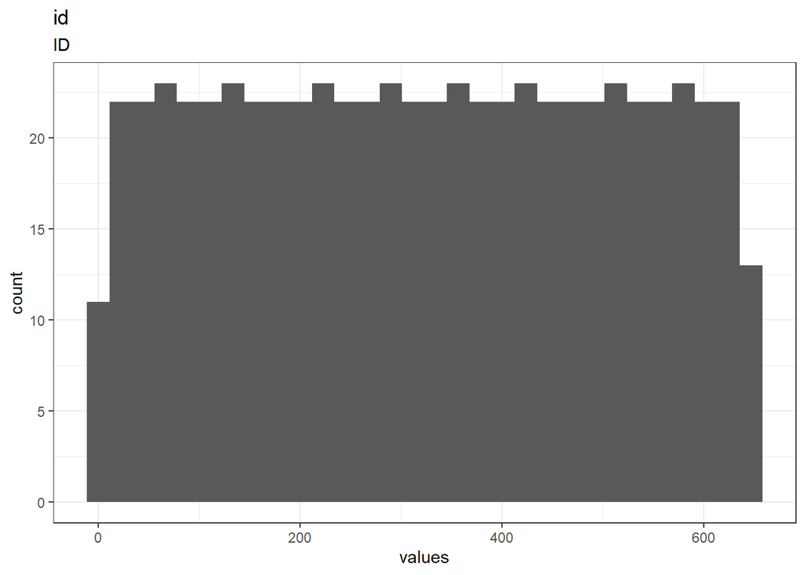

0 missing values.

#### Summary statistics

| name | label | data_type | missing | complete | n | mean | sd | p0 | p25 | p50 | p75 | p100 | hist |
| --- | --- | --- | --- | --- | --- | --- | --- | --- | --- | --- | --- | --- | --- |
| id | ID | numeric | 0 | 648 | 648 | 324.5 | 187.21 | 1 | 162.75 | 324.5 | 486.25 | 648 | ▇▇▇▇▇▇▇▇ |

### startdate

Start date

#### Distribution

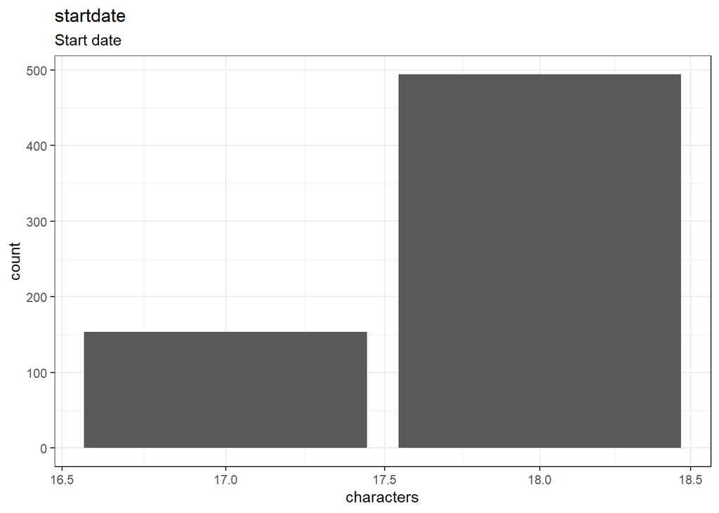

0 missing values.

#### Summary statistics

| name | label | data_type | missing | complete | n | empty | n_unique | min | max |
| --- | --- | --- | --- | --- | --- | --- | --- | --- | --- |
| startdate | Start date | character | 0 | 648 | 648 | 0 | 643 | 17 | 18 |

### enddate

End Date

#### Distribution

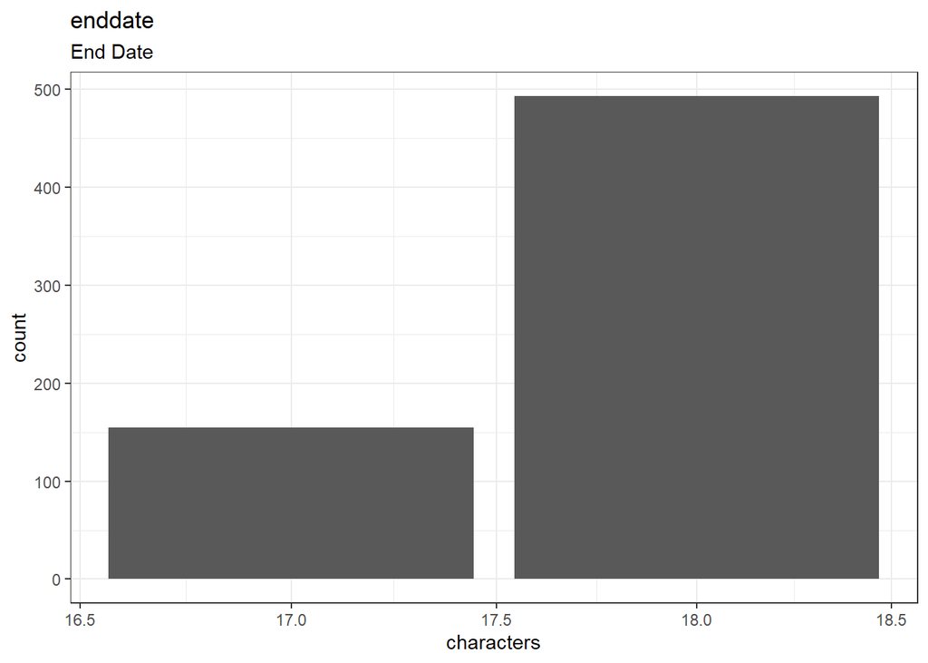

0 missing values.

#### Summary statistics

| name | label | data_type | missing | complete | n | empty | n_unique | min | max |
| --- | --- | --- | --- | --- | --- | --- | --- | --- | --- |
| enddate | End Date | character | 0 | 648 | 648 | 0 | 643 | 17 | 18 |

### treatment

Treatment group

#### Distribution

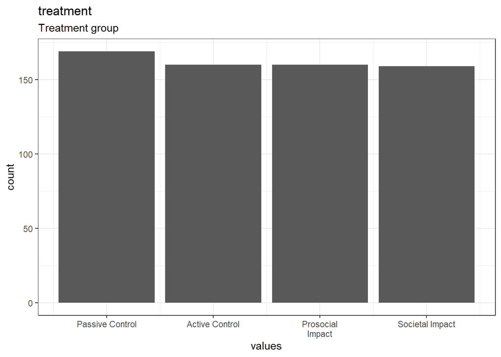

0 missing values.

#### Summary statistics

| name | label | data_type | value_labels | missing | complete | n | mean | sd | p0 | p25 | p50 | p75 | p100 | hist |
| --- | --- | --- | --- | --- | --- | --- | --- | --- | --- | --- | --- | --- | --- | --- |
| treatment | Treatment group | numeric | 1. Passive Control, 2. Active Control, 3. Prosocial Impact, 4. Societal Impact | 0 | 648 | 648 | 2.48 | 1.12 | 1 | 1 | 2 | 3 | 4 | ▇▁▇▁▁▇▁▇ |

#### Value labels

- **Passive Control**: *1*
- **Active Control**: *2*
- **Prosocial Impact**: *3*
- **Societal Impact**: *4*

### paffect1

Positive

#### Distribution

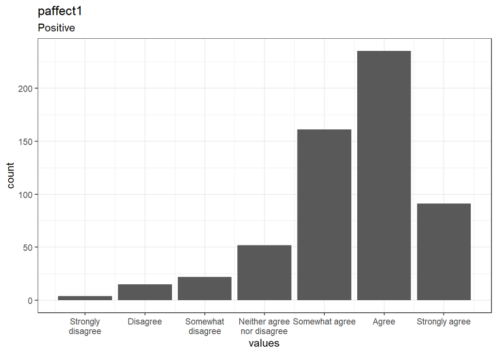

68 missing values.

#### Summary statistics

| name | label | data_type | value_labels | missing | complete | n | mean | sd | p0 | p25 | p50 | p75 | p100 | hist |
| --- | --- | --- | --- | --- | --- | --- | --- | --- | --- | --- | --- | --- | --- | --- |
| paffect1 | Positive | numeric | 1. Strongly disagree, 2. Disagree, 3. Somewhat disagree, 4. Neither agree nor disagree, 5. Somewhat agree, 6. Agree, 7. Strongly agree | 68 | 580 | 648 | 5.45 | 1.19 | 1 | 5 | 6 | 6 | 7 | ▁▁▁▂▁▆▇▃ |

#### Value labels

- **Strongly disagree**: *1*
- **Disagree**: *2*
- **Somewhat disagree**: *3*
- **Neither agree nor disagree**: *4*
- **Somewhat agree**: *5*
- **Agree**: *6*
- **Strongly agree**: *7*

### paffect2

Good

#### Distribution

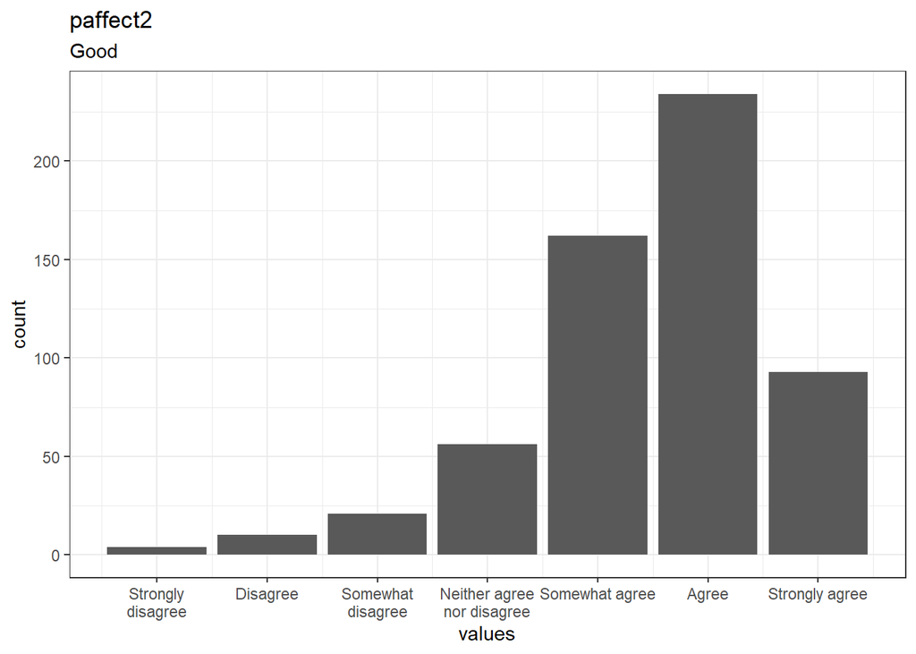

68 missing values.

#### Summary statistics

| name | label | data_type | value_labels | missing | complete | n | mean | sd | p0 | p25 | p50 | p75 | p100 | hist |
| --- | --- | --- | --- | --- | --- | --- | --- | --- | --- | --- | --- | --- | --- | --- |
| paffect2 | Good | numeric | 1. Strongly disagree, 2. Disagree, 3. Somewhat disagree, 4. Neither agree nor disagree, 5. Somewhat agree, 6. Agree, 7. Strongly agree | 68 | 580 | 648 | 5.48 | 1.15 | 1 | 5 | 6 | 6 | 7 | ▁▁▁▂▁▆▇▃ |

#### Value labels

- **Strongly disagree**: *1*
- **Disagree**: *2*
- **Somewhat disagree**: *3*
- **Neither agree nor disagree**: *4*
- **Somewhat agree**: *5*
- **Agree**: *6*
- **Strongly agree**: *7*

### paffect3

Pleasant

#### Distribution

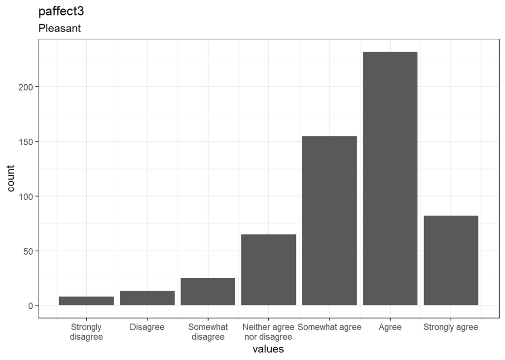

68 missing values.

#### Summary statistics

| name | label | data_type | value_labels | missing | complete | n | mean | sd | p0 | p25 | p50 | p75 | p100 | hist |
| --- | --- | --- | --- | --- | --- | --- | --- | --- | --- | --- | --- | --- | --- | --- |
| paffect3 | Pleasant | numeric | 1. Strongly disagree, 2. Disagree, 3. Somewhat disagree, 4. Neither agree nor disagree, 5. Somewhat agree, 6. Agree, 7. Strongly agree | 68 | 580 | 648 | 5.36 | 1.24 | 1 | 5 | 6 | 6 | 7 | ▁▁▁▂▁▆▇▃ |

#### Value labels

- **Strongly disagree**: *1*
- **Disagree**: *2*
- **Somewhat disagree**: *3*
- **Neither agree nor disagree**: *4*
- **Somewhat agree**: *5*
- **Agree**: *6*
- **Strongly agree**: *7*

### paffect4

Happy

#### Distribution

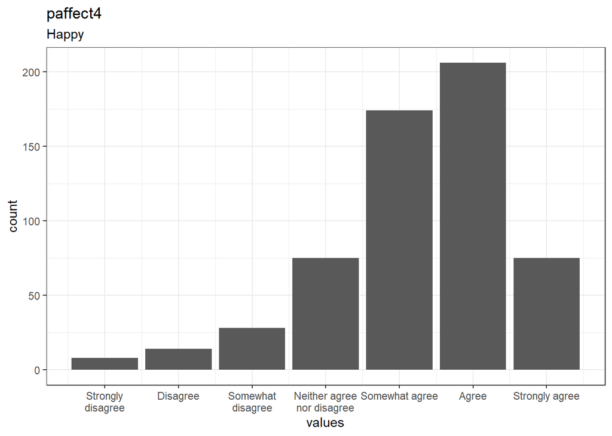

68 missing values.

#### Summary statistics

| name | label | data_type | value_labels | missing | complete | n | mean | sd | p0 | p25 | p50 | p75 | p100 | hist |
| --- | --- | --- | --- | --- | --- | --- | --- | --- | --- | --- | --- | --- | --- | --- |
| paffect4 | Happy | numeric | 1. Strongly disagree, 2. Disagree, 3. Somewhat disagree, 4. Neither agree nor disagree, 5. Somewhat agree, 6. Agree, 7. Strongly agree | 68 | 580 | 648 | 5.26 | 1.25 | 1 | 5 | 5 | 6 | 7 | ▁▁▁▃▁▇▇▃ |

#### Value labels

- **Strongly disagree**: *1*
- **Disagree**: *2*
- **Somewhat disagree**: *3*
- **Neither agree nor disagree**: *4*
- **Somewhat agree**: *5*
- **Agree**: *6*
- **Strongly agree**: *7*

### paffect5

Joyful

#### Distribution

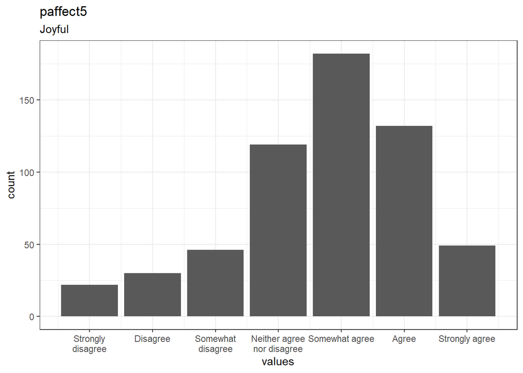

68 missing values.

#### Summary statistics

| name | label | data_type | value_labels | missing | complete | n | mean | sd | p0 | p25 | p50 | p75 | p100 | hist |
| --- | --- | --- | --- | --- | --- | --- | --- | --- | --- | --- | --- | --- | --- | --- |
| paffect5 | Joyful | numeric | 1. Strongly disagree, 2. Disagree, 3. Somewhat disagree, 4. Neither agree nor disagree, 5. Somewhat agree, 6. Agree, 7. Strongly agree | 68 | 580 | 648 | 4.73 | 1.45 | 1 | 4 | 5 | 6 | 7 | ▁▁▂▅▁▇▆▂ |

#### Value labels

- **Strongly disagree**: *1*
- **Disagree**: *2*
- **Somewhat disagree**: *3*
- **Neither agree nor disagree**: *4*
- **Somewhat agree**: *5*
- **Agree**: *6*
- **Strongly agree**: *7*

### paffect6

Contented

#### Distribution

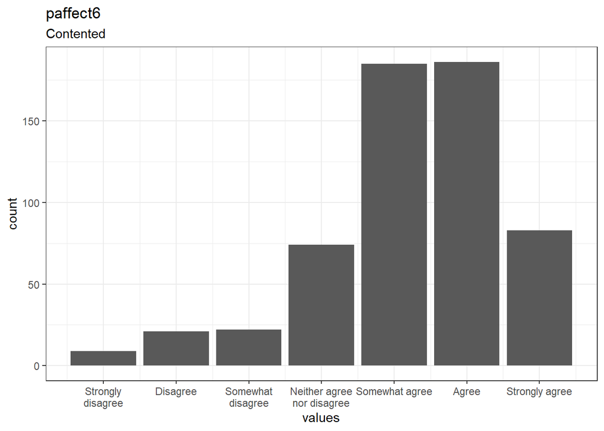

68 missing values.

#### Summary statistics

| name | label | data_type | value_labels | missing | complete | n | mean | sd | p0 | p25 | p50 | p75 | p100 | hist |
| --- | --- | --- | --- | --- | --- | --- | --- | --- | --- | --- | --- | --- | --- | --- |
| paffect6 | Contented | numeric | 1. Strongly disagree, 2. Disagree, 3. Somewhat disagree, 4. Neither agree nor disagree, 5. Somewhat agree, 6. Agree, 7. Strongly agree | 68 | 580 | 648 | 5.23 | 1.3 | 1 | 5 | 5 | 6 | 7 | ▁▁▁▃▁▇▇▃ |

#### Value labels

- **Strongly disagree**: *1*
- **Disagree**: *2*
- **Somewhat disagree**: *3*
- **Neither agree nor disagree**: *4*
- **Somewhat agree**: *5*
- **Agree**: *6*
- **Strongly agree**: *7*

### naffect1

Negative

#### Distribution

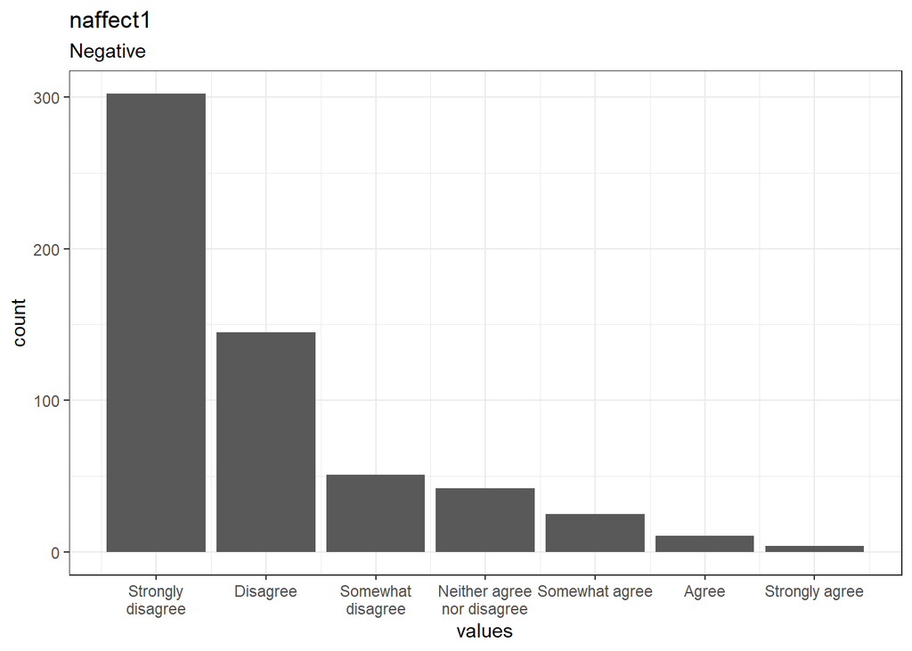

68 missing values.

#### Summary statistics

| name | label | data_type | value_labels | missing | complete | n | mean | sd | p0 | p25 | p50 | p75 | p100 | hist |
| --- | --- | --- | --- | --- | --- | --- | --- | --- | --- | --- | --- | --- | --- | --- |
| naffect1 | Negative | numeric | 1. Strongly disagree, 2. Disagree, 3. Somewhat disagree, 4. Neither agree nor disagree, 5. Somewhat agree, 6. Agree, 7. Strongly agree | 68 | 580 | 648 | 1.95 | 1.33 | 1 | 1 | 1 | 2 | 7 | ▇▃▂▁▁▁▁▁ |

#### Value labels

- **Strongly disagree**: *1*
- **Disagree**: *2*
- **Somewhat disagree**: *3*
- **Neither agree nor disagree**: *4*
- **Somewhat agree**: *5*
- **Agree**: *6*
- **Strongly agree**: *7*

### naffect2

Bad

#### Distribution

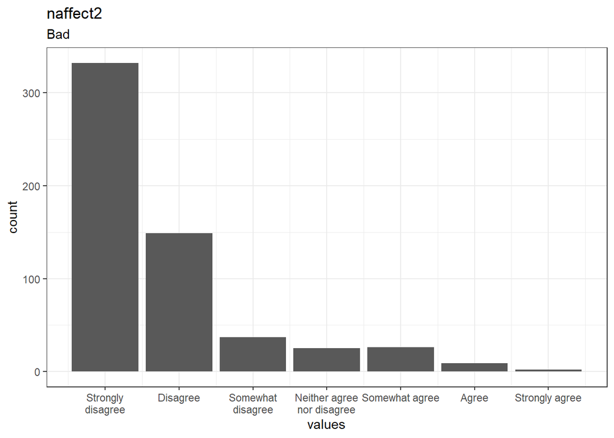

68 missing values.

#### Summary statistics

| name | label | data_type | value_labels | missing | complete | n | mean | sd | p0 | p25 | p50 | p75 | p100 | hist |
| --- | --- | --- | --- | --- | --- | --- | --- | --- | --- | --- | --- | --- | --- | --- |
| naffect2 | Bad | numeric | 1. Strongly disagree, 2. Disagree, 3. Somewhat disagree, 4. Neither agree nor disagree, 5. Somewhat agree, 6. Agree, 7. Strongly agree | 68 | 580 | 648 | 1.79 | 1.23 | 1 | 1 | 1 | 2 | 7 | ▇▃▁▁▁▁▁▁ |

#### Value labels

- **Strongly disagree**: *1*
- **Disagree**: *2*
- **Somewhat disagree**: *3*
- **Neither agree nor disagree**: *4*
- **Somewhat agree**: *5*
- **Agree**: *6*
- **Strongly agree**: *7*

### naffect3

Unpleasant

#### Distribution

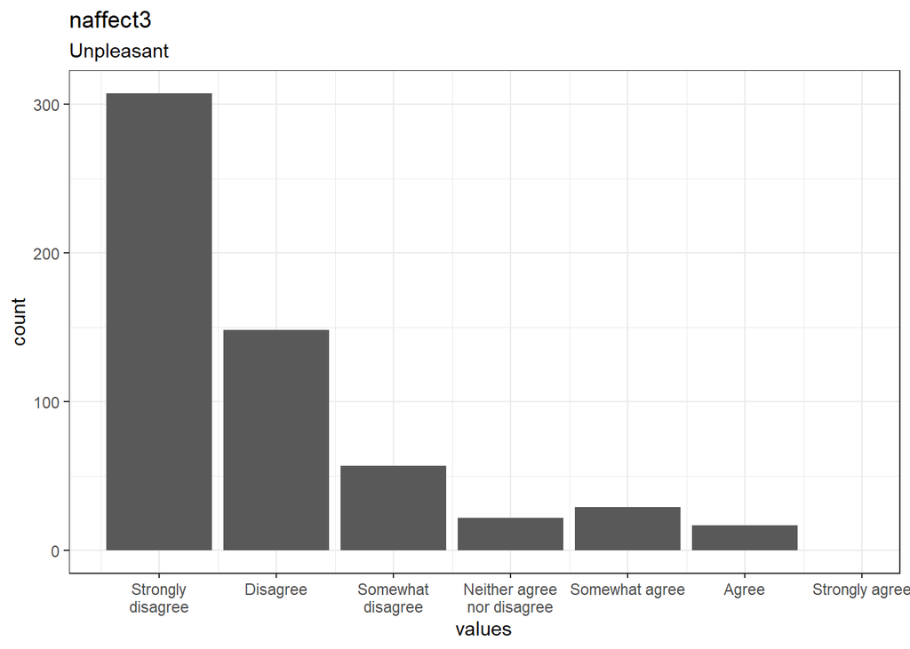

68 missing values.

#### Summary statistics

| name | label | data_type | value_labels | missing | complete | n | mean | sd | p0 | p25 | p50 | p75 | p100 | hist |
| --- | --- | --- | --- | --- | --- | --- | --- | --- | --- | --- | --- | --- | --- | --- |
| naffect3 | Unpleasant | numeric | 1. Strongly disagree, 2. Disagree, 3. Somewhat disagree, 4. Neither agree nor disagree, 5. Somewhat agree, 6. Agree, 7. Strongly agree | 68 | 580 | 648 | 1.91 | 1.3 | 1 | 1 | 1 | 2 | 6 | ▇▃▁▂▁▁▁▁ |

#### Value labels

- **Strongly disagree**: *1*
- **Disagree**: *2*
- **Somewhat disagree**: *3*
- **Neither agree nor disagree**: *4*
- **Somewhat agree**: *5*
- **Agree**: *6*
- **Strongly agree**: *7*

### naffect4

Sad

#### Distribution

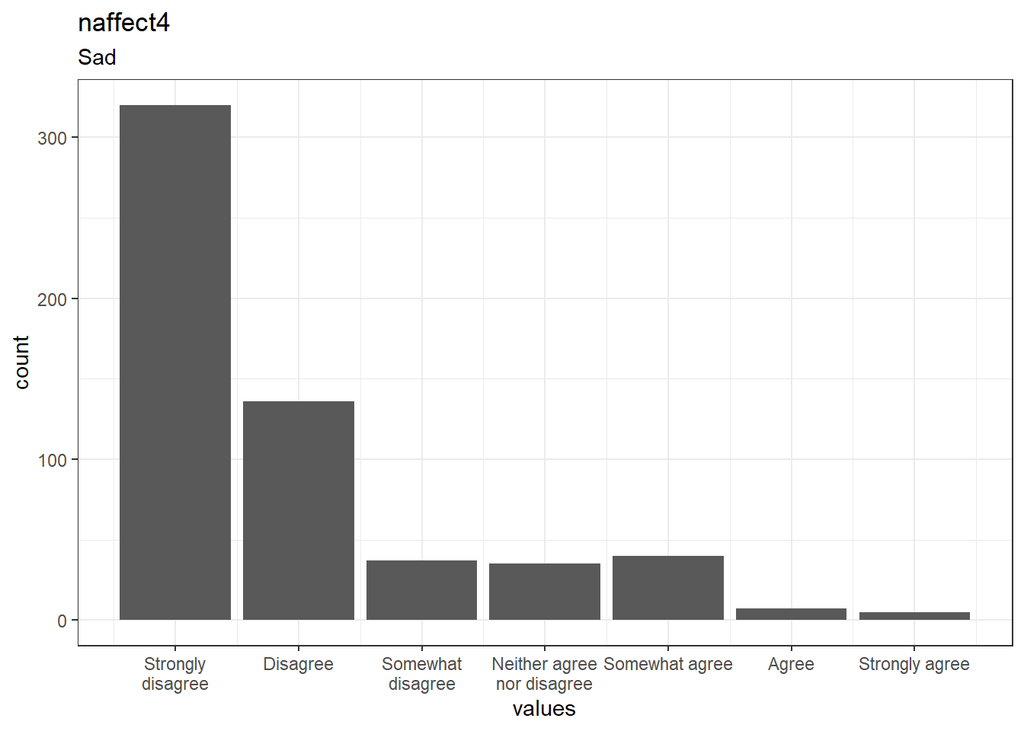

68 missing values.

#### Summary statistics

| name | label | data_type | value_labels | missing | complete | n | mean | sd | p0 | p25 | p50 | p75 | p100 | hist |
| --- | --- | --- | --- | --- | --- | --- | --- | --- | --- | --- | --- | --- | --- | --- |
| naffect4 | Sad | numeric | 1. Strongly disagree, 2. Disagree, 3. Somewhat disagree, 4. Neither agree nor disagree, 5. Somewhat agree, 6. Agree, 7. Strongly agree | 68 | 580 | 648 | 1.93 | 1.37 | 1 | 1 | 1 | 2 | 7 | ▇▃▁▁▁▁▁▁ |

#### Value labels

- **Strongly disagree**: *1*
- **Disagree**: *2*
- **Somewhat disagree**: *3*
- **Neither agree nor disagree**: *4*
- **Somewhat agree**: *5*
- **Agree**: *6*
- **Strongly agree**: *7*

### naffect5

Afraid

#### Distribution

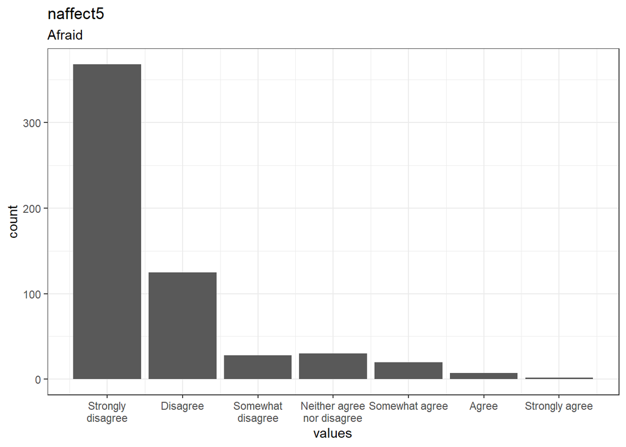

68 missing values.

#### Summary statistics

| name | label | data_type | value_labels | missing | complete | n | mean | sd | p0 | p25 | p50 | p75 | p100 | hist |
| --- | --- | --- | --- | --- | --- | --- | --- | --- | --- | --- | --- | --- | --- | --- |
| naffect5 | Afraid | numeric | 1. Strongly disagree, 2. Disagree, 3. Somewhat disagree, 4. Neither agree nor disagree, 5. Somewhat agree, 6. Agree, 7. Strongly agree | 68 | 580 | 648 | 1.69 | 1.18 | 1 | 1 | 1 | 2 | 7 | ▇▃▁▁▁▁▁▁ |

#### Value labels

- **Strongly disagree**: *1*
- **Disagree**: *2*
- **Somewhat disagree**: *3*
- **Neither agree nor disagree**: *4*
- **Somewhat agree**: *5*
- **Agree**: *6*
- **Strongly agree**: *7*

### naffect6

Angry

#### Distribution

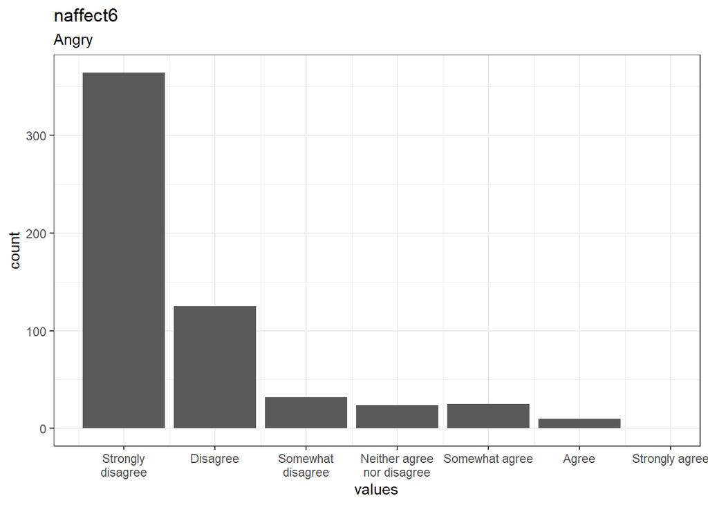

68 missing values.

#### Summary statistics

| name | label | data_type | value_labels | missing | complete | n | mean | sd | p0 | p25 | p50 | p75 | p100 | hist |
| --- | --- | --- | --- | --- | --- | --- | --- | --- | --- | --- | --- | --- | --- | --- |
| naffect6 | Angry | numeric | 1. Strongly disagree, 2. Disagree, 3. Somewhat disagree, 4. Neither agree nor disagree, 5. Somewhat agree, 6. Agree, 7. Strongly agree | 68 | 580 | 648 | 1.71 | 1.2 | 1 | 1 | 1 | 2 | 6 | ▇▃▁▁▁▁▁▁ |

#### Value labels

- **Strongly disagree**: *1*
- **Disagree**: *2*
- **Somewhat disagree**: *3*
- **Neither agree nor disagree**: *4*
- **Somewhat agree**: *5*
- **Agree**: *6*
- **Strongly agree**: *7*

### willingnessjobrec1

How likely would you recommend your job to your friends?

#### Distribution

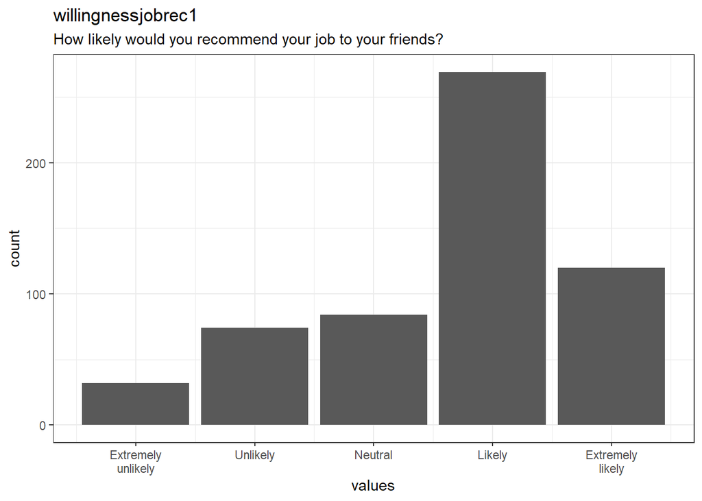

69 missing values.

#### Summary statistics

| name | label | data_type | value_labels | missing | complete | n | mean | sd | p0 | p25 | p50 | p75 | p100 | hist |
| --- | --- | --- | --- | --- | --- | --- | --- | --- | --- | --- | --- | --- | --- | --- |
| willingnessjobrec1 | How likely would you recommend your job to your friends? | numeric | 1. Extremely unlikely, 2. Unlikely, 3. Neutral, 4. Likely, 5. Extremely likely | 69 | 579 | 648 | 3.64 | 1.11 | 1 | 3 | 4 | 4 | 5 | ▁▂▁▂▁▇▁▃ |

#### Value labels

- **Extremely unlikely**: *1*
- **Unlikely**: *2*
- **Neutral**: *3*
- **Likely**: *4*
- **Extremely likely**: *5*

### willingnessjobrec2

How likely would you tell your friends NOT to do the same job you do?

#### Distribution

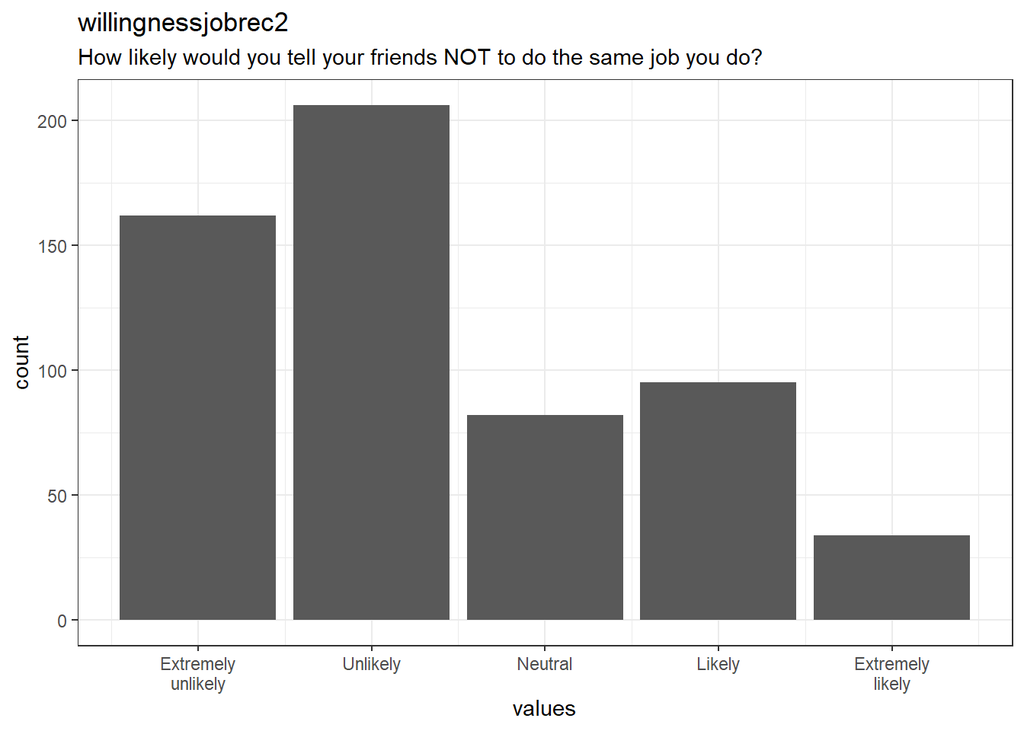

69 missing values.

#### Summary statistics

| name | label | data_type | value_labels | missing | complete | n | mean | sd | p0 | p25 | p50 | p75 | p100 | hist |
| --- | --- | --- | --- | --- | --- | --- | --- | --- | --- | --- | --- | --- | --- | --- |
| willingnessjobrec2 | How likely would you tell your friends NOT to do the same job you do? | numeric | 1. Extremely unlikely, 2. Unlikely, 3. Neutral, 4. Likely, 5. Extremely likely | 69 | 579 | 648 | 2.37 | 1.21 | 1 | 1 | 2 | 3 | 5 | ▆▇▁▃▁▃▁▁ |

#### Value labels

- **Extremely unlikely**: *1*
- **Unlikely**: *2*
- **Neutral**: *3*
- **Likely**: *4*
- **Extremely likely**: *5*

### turnover1

If I have my own way, I will be working for my organization one year from now.

#### Distribution

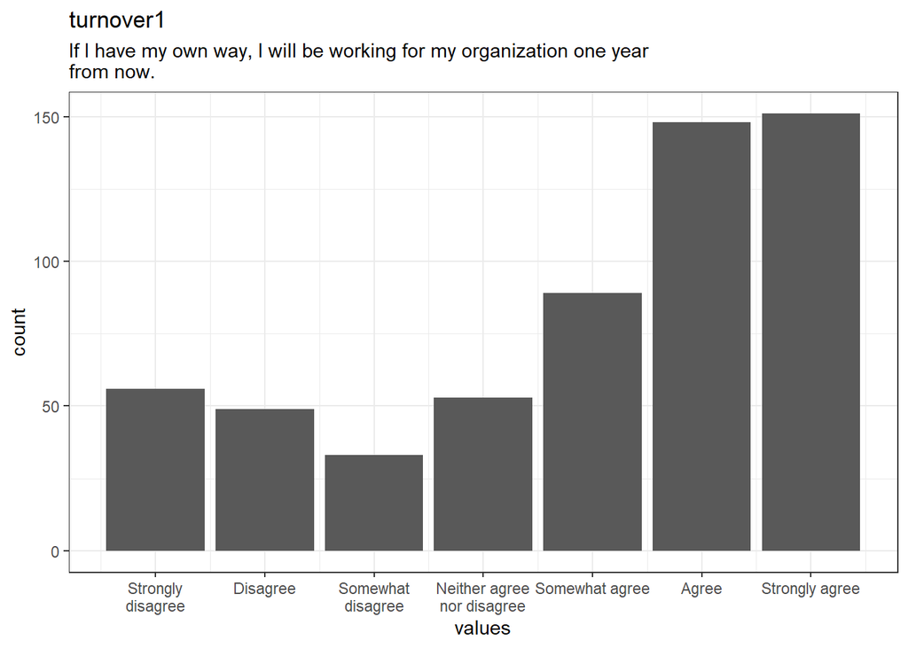

69 missing values.

#### Summary statistics

| name | label | data_type | value_labels | missing | complete | n | mean | sd | p0 | p25 | p50 | p75 | p100 | hist |
| --- | --- | --- | --- | --- | --- | --- | --- | --- | --- | --- | --- | --- | --- | --- |
| turnover1 | If I have my own way, I will be working for my organization one year from now. | numeric | 1. Strongly disagree, 2. Disagree, 3. Somewhat disagree, 4. Neither agree nor disagree, 5. Somewhat agree, 6. Agree, 7. Strongly agree | 69 | 579 | 648 | 4.93 | 1.98 | 1 | 4 | 6 | 7 | 7 | ▃▂▂▃▁▅▇▇ |

#### Value labels

- **Strongly disagree**: *1*
- **Disagree**: *2*
- **Somewhat disagree**: *3*
- **Neither agree nor disagree**: *4*
- **Somewhat agree**: *5*
- **Agree**: *6*
- **Strongly agree**: *7*

### turnover2

I frequently think of quitting my job.

#### Distribution

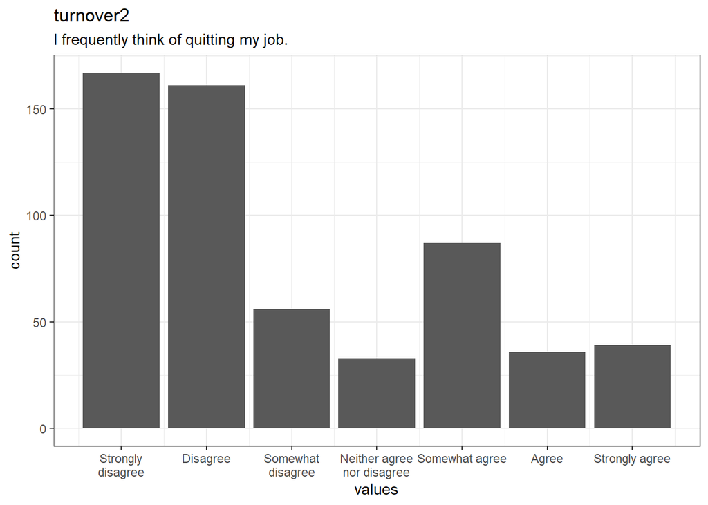

69 missing values.

#### Summary statistics

| name | label | data_type | value_labels | missing | complete | n | mean | sd | p0 | p25 | p50 | p75 | p100 | hist |
| --- | --- | --- | --- | --- | --- | --- | --- | --- | --- | --- | --- | --- | --- | --- |
| turnover2 | I frequently think of quitting my job. | numeric | 1. Strongly disagree, 2. Disagree, 3. Somewhat disagree, 4. Neither agree nor disagree, 5. Somewhat agree, 6. Agree, 7. Strongly agree | 69 | 579 | 648 | 2.96 | 1.93 | 1 | 1 | 2 | 5 | 7 | ▇▇▃▂▁▅▂▂ |

#### Value labels

- **Strongly disagree**: *1*
- **Disagree**: *2*
- **Somewhat disagree**: *3*
- **Neither agree nor disagree**: *4*
- **Somewhat agree**: *5*
- **Agree**: *6*
- **Strongly agree**: *7*

### turnover3

I am planning to search for a new job during the next 12 months.

#### Distribution

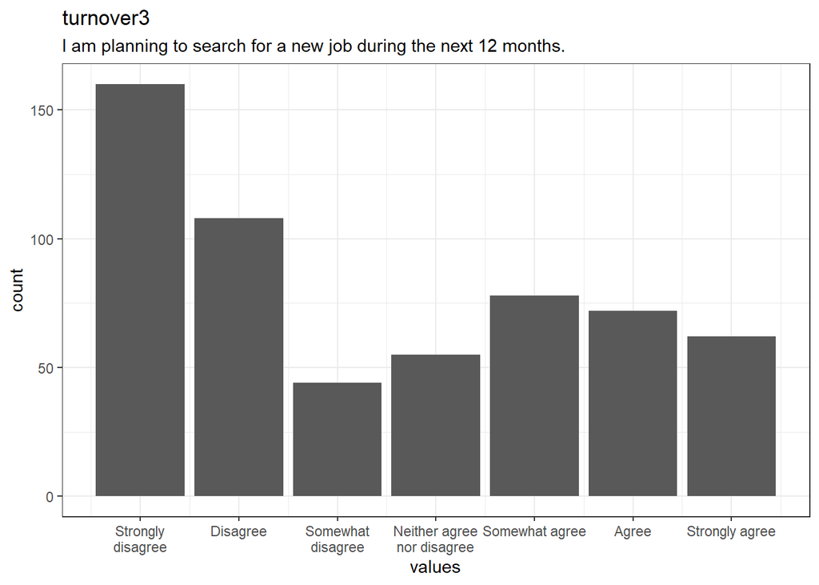

69 missing values.

#### Summary statistics

| name | label | data_type | value_labels | missing | complete | n | mean | sd | p0 | p25 | p50 | p75 | p100 | hist |
| --- | --- | --- | --- | --- | --- | --- | --- | --- | --- | --- | --- | --- | --- | --- |
| turnover3 | I am planning to search for a new job during the next 12 months. | numeric | 1. Strongly disagree, 2. Disagree, 3. Somewhat disagree, 4. Neither agree nor disagree, 5. Somewhat agree, 6. Agree, 7. Strongly agree | 69 | 579 | 648 | 3.43 | 2.14 | 1 | 1 | 3 | 5 | 7 | ▇▆▂▃▁▃▃▃ |

#### Value labels

- **Strongly disagree**: *1*
- **Disagree**: *2*
- **Somewhat disagree**: *3*
- **Neither agree nor disagree**: *4*
- **Somewhat agree**: *5*
- **Agree**: *6*
- **Strongly agree**: *7*

### manipulationcheck

Think about the beginning of the survey and the formulation of the first question regarding the content of your job: What exactly did we ask you to reflect upon?

#### Distribution

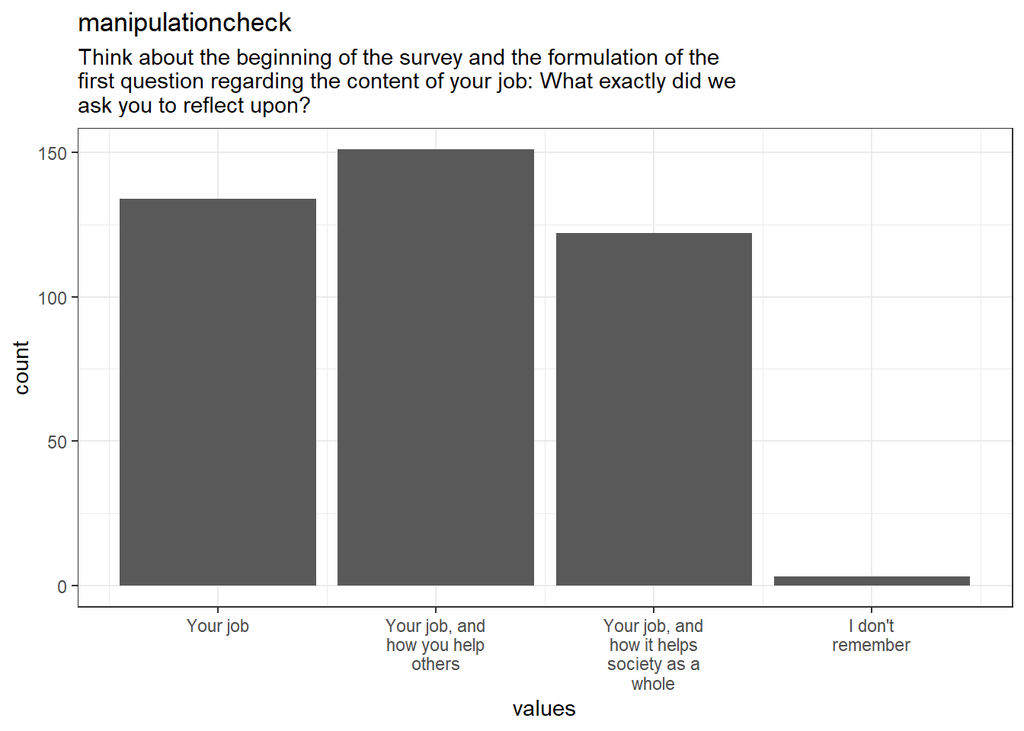

238 missing values.

#### Summary statistics

| name | label | data_type | value_labels | missing | complete | n | mean | sd | p0 | p25 | p50 | p75 | p100 | hist |
| --- | --- | --- | --- | --- | --- | --- | --- | --- | --- | --- | --- | --- | --- | --- |
| manipulationcheck | Think about the beginning of the survey and the formulation of the first question regarding the content of your job: What exactly did we ask you to reflect upon? | numeric | 1. Your job, 2. Your job, and how you help others, 3. Your job, and how it helps society as a whole, 4. I don’t remember | 238 | 410 | 648 | 1.99 | 0.81 | 1 | 1 | 2 | 3 | 4 | ▇▁▇▁▁▆▁▁ |

#### Value labels

- **Your job**: *1*
- **Your job, and how you help others**: *2*
- **Your job, and how it helps society as a whole**: *3*
- **I don’t remember**: *4*

### prosocialimpact1

I am very conscious of the positive impact that my work has on others.

#### Distribution

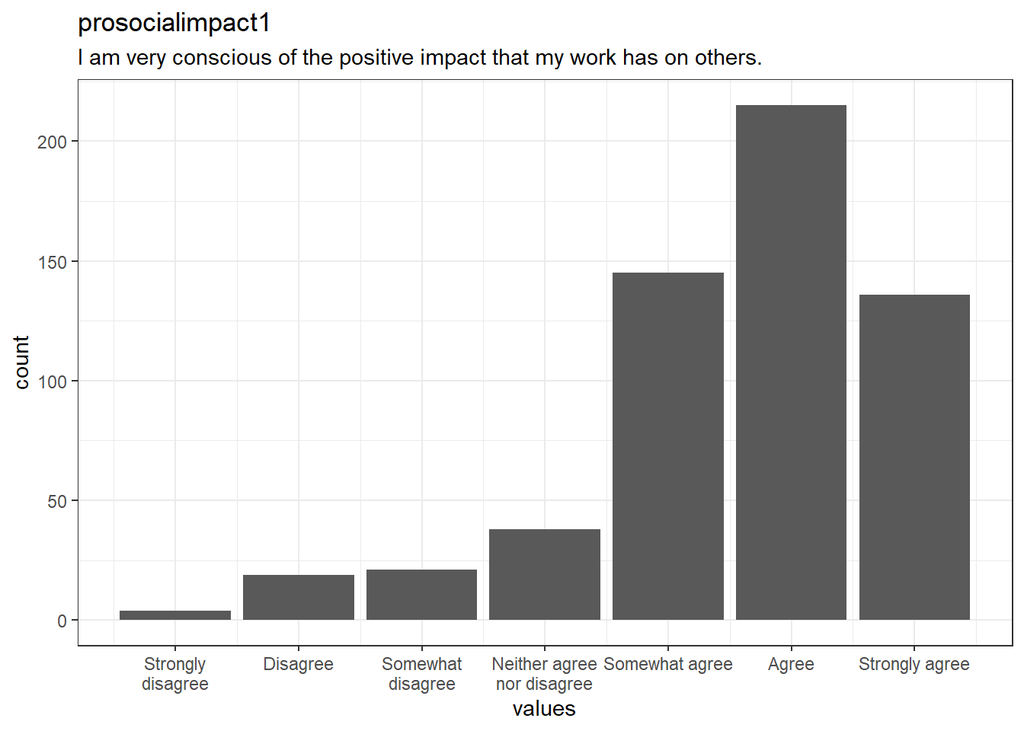

70 missing values.

#### Summary statistics

| name | label | data_type | value_labels | missing | complete | n | mean | sd | p0 | p25 | p50 | p75 | p100 | hist |
| --- | --- | --- | --- | --- | --- | --- | --- | --- | --- | --- | --- | --- | --- | --- |
| prosocialimpact1 | I am very conscious of the positive impact that my work has on others. | numeric | 1. Strongly disagree, 2. Disagree, 3. Somewhat disagree, 4. Neither agree nor disagree, 5. Somewhat agree, 6. Agree, 7. Strongly agree | 70 | 578 | 648 | 5.58 | 1.26 | 1 | 5 | 6 | 6 | 7 | ▁▁▁▂▁▆▇▅ |

#### Value labels

- **Strongly disagree**: *1*
- **Disagree**: *2*
- **Somewhat disagree**: *3*
- **Neither agree nor disagree**: *4*
- **Somewhat agree**: *5*
- **Agree**: *6*
- **Strongly agree**: *7*

### prosocialimpact2

I am very aware of the ways in which my work is benefiting others.

#### Distribution

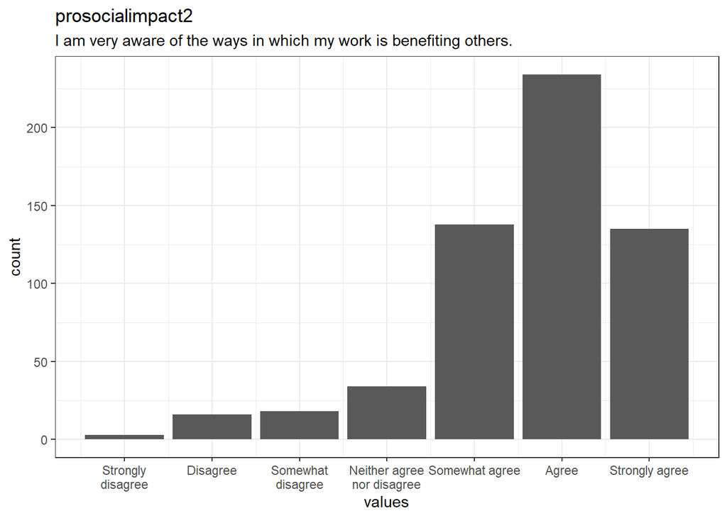

70 missing values.

#### Summary statistics

| name | label | data_type | value_labels | missing | complete | n | mean | sd | p0 | p25 | p50 | p75 | p100 | hist |
| --- | --- | --- | --- | --- | --- | --- | --- | --- | --- | --- | --- | --- | --- | --- |
| prosocialimpact2 | I am very aware of the ways in which my work is benefiting others. | numeric | 1. Strongly disagree, 2. Disagree, 3. Somewhat disagree, 4. Neither agree nor disagree, 5. Somewhat agree, 6. Agree, 7. Strongly agree | 70 | 578 | 648 | 5.65 | 1.2 | 1 | 5 | 6 | 6 | 7 | ▁▁▁▁▁▅▇▅ |

#### Value labels

- **Strongly disagree**: *1*
- **Disagree**: *2*
- **Somewhat disagree**: *3*
- **Neither agree nor disagree**: *4*
- **Somewhat agree**: *5*
- **Agree**: *6*
- **Strongly agree**: *7*

### prosocialimpact3

I feel that I can have a positive impact on others through my work.

#### Distribution

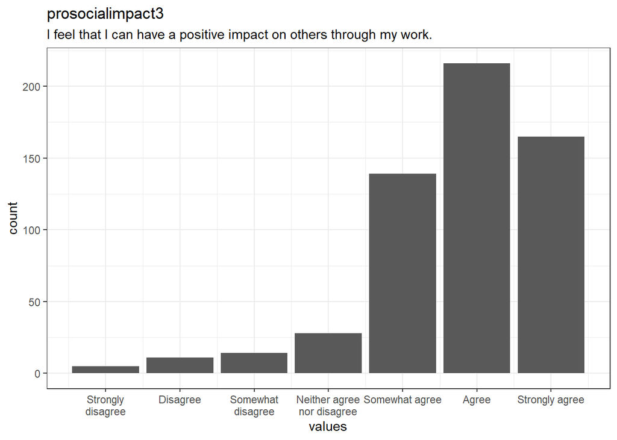

70 missing values.

#### Summary statistics

| name | label | data_type | value_labels | missing | complete | n | mean | sd | p0 | p25 | p50 | p75 | p100 | hist |
| --- | --- | --- | --- | --- | --- | --- | --- | --- | --- | --- | --- | --- | --- | --- |
| prosocialimpact3 | I feel that I can have a positive impact on others through my work. | numeric | 1. Strongly disagree, 2. Disagree, 3. Somewhat disagree, 4. Neither agree nor disagree, 5. Somewhat agree, 6. Agree, 7. Strongly agree | 70 | 578 | 648 | 5.76 | 1.18 | 1 | 5 | 6 | 7 | 7 | ▁▁▁▁▁▅▇▆ |

#### Value labels

- **Strongly disagree**: *1*
- **Disagree**: *2*
- **Somewhat disagree**: *3*
- **Neither agree nor disagree**: *4*
- **Somewhat agree**: *5*
- **Agree**: *6*
- **Strongly agree**: *7*

### societalimpact1

I am very conscious of the positive impact that my work has on society at large.

#### Distribution

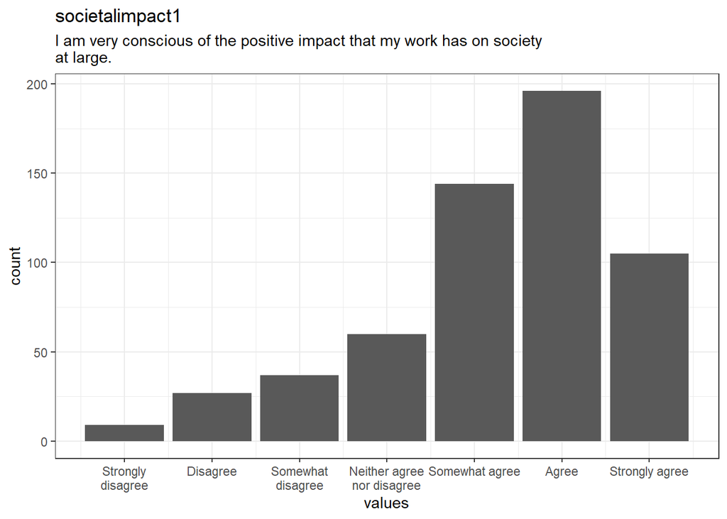

70 missing values.

#### Summary statistics

| name | label | data_type | value_labels | missing | complete | n | mean | sd | p0 | p25 | p50 | p75 | p100 | hist |
| --- | --- | --- | --- | --- | --- | --- | --- | --- | --- | --- | --- | --- | --- | --- |
| societalimpact1 | I am very conscious of the positive impact that my work has on society at large. | numeric | 1. Strongly disagree, 2. Disagree, 3. Somewhat disagree, 4. Neither agree nor disagree, 5. Somewhat agree, 6. Agree, 7. Strongly agree | 70 | 578 | 648 | 5.27 | 1.42 | 1 | 5 | 6 | 6 | 7 | ▁▁▂▂▁▆▇▅ |

#### Value labels

- **Strongly disagree**: *1*
- **Disagree**: *2*
- **Somewhat disagree**: *3*
- **Neither agree nor disagree**: *4*
- **Somewhat agree**: *5*
- **Agree**: *6*
- **Strongly agree**: *7*

### societalimpact2

I am very aware of the ways in which my work is benefiting the society.

#### Distribution

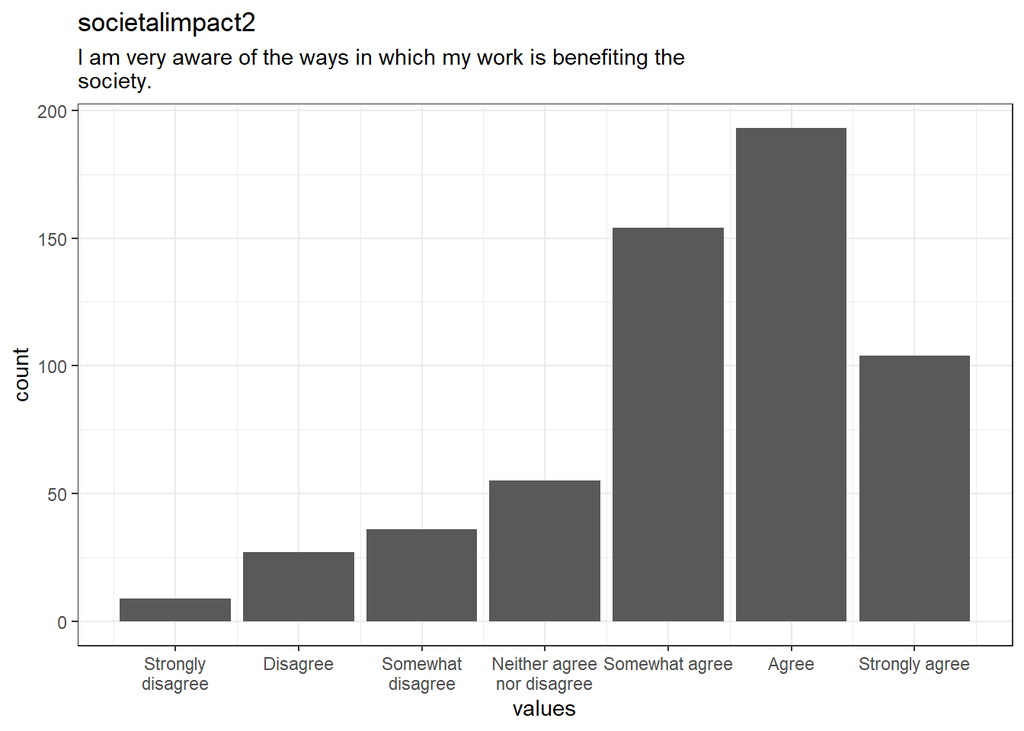

70 missing values.

#### Summary statistics

| name | label | data_type | value_labels | missing | complete | n | mean | sd | p0 | p25 | p50 | p75 | p100 | hist |
| --- | --- | --- | --- | --- | --- | --- | --- | --- | --- | --- | --- | --- | --- | --- |
| societalimpact2 | I am very aware of the ways in which my work is benefiting the society. | numeric | 1. Strongly disagree, 2. Disagree, 3. Somewhat disagree, 4. Neither agree nor disagree, 5. Somewhat agree, 6. Agree, 7. Strongly agree | 70 | 578 | 648 | 5.27 | 1.41 | 1 | 5 | 6 | 6 | 7 | ▁▁▂▂▁▆▇▅ |

#### Value labels

- **Strongly disagree**: *1*
- **Disagree**: *2*
- **Somewhat disagree**: *3*
- **Neither agree nor disagree**: *4*
- **Somewhat agree**: *5*
- **Agree**: *6*
- **Strongly agree**: *7*

### societalimpact3

I feel that I can have a positive impact on society in general through my work.

#### Distribution

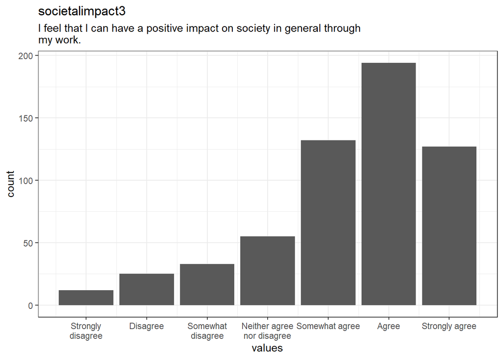

70 missing values.

#### Summary statistics

| name | label | data_type | value_labels | missing | complete | n | mean | sd | p0 | p25 | p50 | p75 | p100 | hist |
| --- | --- | --- | --- | --- | --- | --- | --- | --- | --- | --- | --- | --- | --- | --- |
| societalimpact3 | I feel that I can have a positive impact on society in general through my work. | numeric | 1. Strongly disagree, 2. Disagree, 3. Somewhat disagree, 4. Neither agree nor disagree, 5. Somewhat agree, 6. Agree, 7. Strongly agree | 70 | 578 | 648 | 5.35 | 1.46 | 1 | 5 | 6 | 6 | 7 | ▁▁▂▂▁▆▇▅ |

#### Value labels

- **Strongly disagree**: *1*
- **Disagree**: *2*
- **Somewhat disagree**: *3*
- **Neither agree nor disagree**: *4*
- **Somewhat agree**: *5*
- **Agree**: *6*
- **Strongly agree**: *7*

### beneficiaries_obj

How often do you have contact with the people who benefit from your work?

#### Distribution

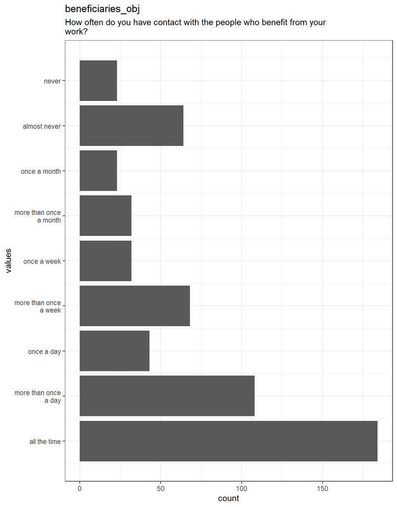

71 missing values.

#### Summary statistics

| name | label | data_type | value_labels | missing | complete | n | mean | sd | p0 | p25 | p50 | p75 | p100 | hist |
| --- | --- | --- | --- | --- | --- | --- | --- | --- | --- | --- | --- | --- | --- | --- |
| beneficiaries_obj | How often do you have contact with the people who benefit from your work? | numeric | 1. all the time, 2. more than once a day, 3. once a day, 4. more than once a week, 5. once a week, 6. more than once a month, 7. once a month, 8. almost never, 9. never | 71 | 577 | 648 | 3.52 | 2.62 | 1 | 1 | 2 | 5 | 9 | ▇▁▂▁▁▁▂▁ |

#### Value labels

- **all the time**: *1*
- **more than once a day**: *2*
- **once a day**: *3*
- **more than once a week**: *4*
- **once a week**: *5*
- **more than once a month**: *6*
- **once a month**: *7*
- **almost never**: *8*
- **never**: *9*

### taskvariety1

To what extent would you say that your work is routine?

#### Distribution

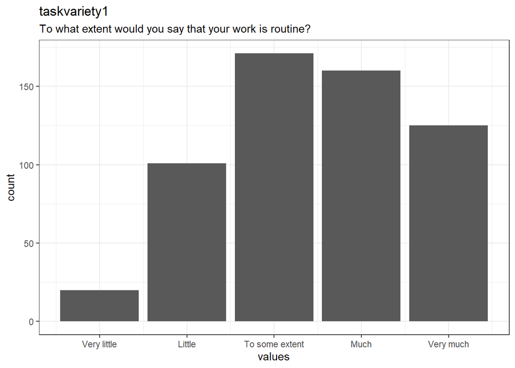

71 missing values.

#### Summary statistics

| name | label | data_type | value_labels | missing | complete | n | mean | sd | p0 | p25 | p50 | p75 | p100 | hist |
| --- | --- | --- | --- | --- | --- | --- | --- | --- | --- | --- | --- | --- | --- | --- |
| taskvariety1 | To what extent would you say that your work is routine? | numeric | 1. Very little, 2. Little, 3. To some extent, 4. Much, 5. Very much | 71 | 577 | 648 | 3.47 | 1.11 | 1 | 3 | 3 | 4 | 5 | ▁▅▁▇▁▇▁▆ |

#### Value labels

- **Very little**: *1*
- **Little**: *2*
- **To some extent**: *3*
- **Much**: *4*
- **Very much**: *5*

### taskvariety2

To what extent do you perform repetitive activities in your job?

#### Distribution

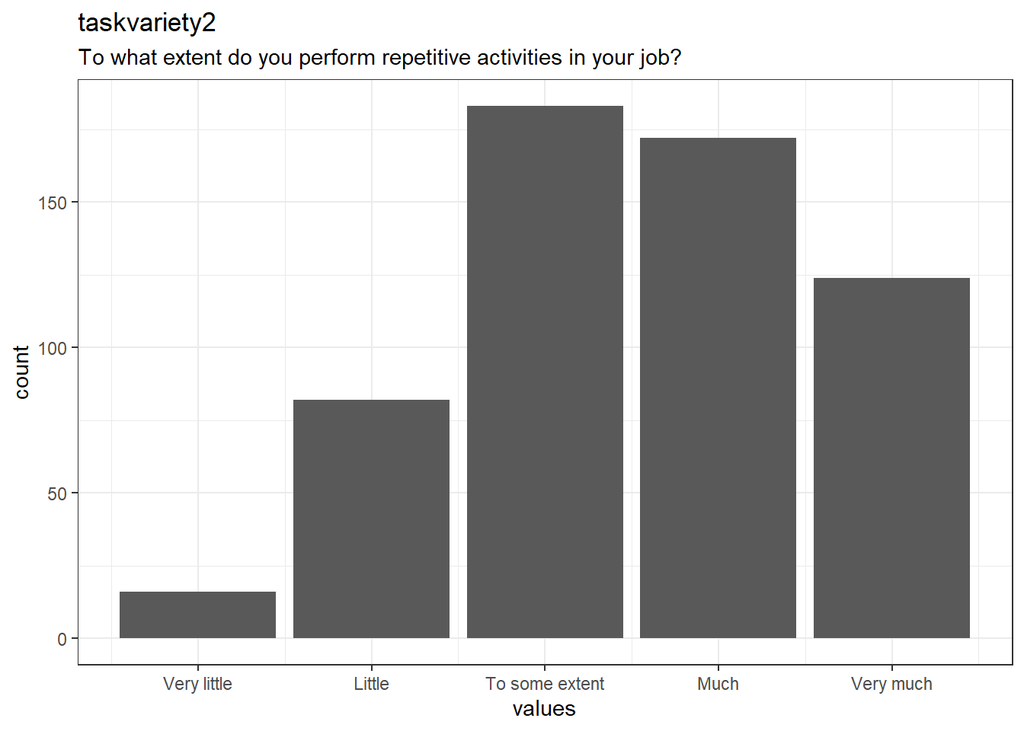

71 missing values.

#### Summary statistics

| name | label | data_type | value_labels | missing | complete | n | mean | sd | p0 | p25 | p50 | p75 | p100 | hist |
| --- | --- | --- | --- | --- | --- | --- | --- | --- | --- | --- | --- | --- | --- | --- |
| taskvariety2 | To what extent do you perform repetitive activities in your job? | numeric | 1. Very little, 2. Little, 3. To some extent, 4. Much, 5. Very much | 71 | 577 | 648 | 3.53 | 1.06 | 1 | 3 | 4 | 4 | 5 | ▁▃▁▇▁▇▁▆ |

#### Value labels

- **Very little**: *1*
- **Little**: *2*
- **To some extent**: *3*
- **Much**: *4*
- **Very much**: *5*

### taskvariety3

To what extent are your job duties repetitive?

#### Distribution

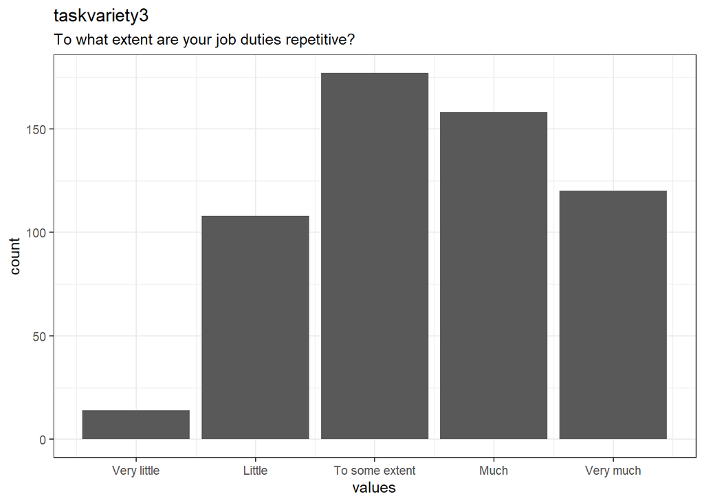

71 missing values.

#### Summary statistics

| name | label | data_type | value_labels | missing | complete | n | mean | sd | p0 | p25 | p50 | p75 | p100 | hist |
| --- | --- | --- | --- | --- | --- | --- | --- | --- | --- | --- | --- | --- | --- | --- |
| taskvariety3 | To what extent are your job duties repetitive? | numeric | 1. Very little, 2. Little, 3. To some extent, 4. Much, 5. Very much | 71 | 577 | 648 | 3.45 | 1.09 | 1 | 3 | 3 | 4 | 5 | ▁▅▁▇▁▇▁▆ |

#### Value labels

- **Very little**: *1*
- **Little**: *2*
- **To some extent**: *3*
- **Much**: *4*
- **Very much**: *5*